# Risk Factor Analysis

## Outcome Variable

**Outcome Variable:** sstunted

## Predictor Variables

**Intervention Variable:** feducyrs

**Adjustment Set:**

unadjusted

## Stratifying Variables

The analysis was stratified on these variable(s):

- agecat
- studyid
- country

## Data Summary

| agecat | studyid | country | feducyrs | sstunted | n_cell | n |
| --- | --- | --- | --- | --- | --- | --- |
| Birth | ki0047075b-MAL-ED | BANGLADESH | Low | 0 | 37 | 144 |
| Birth | ki0047075b-MAL-ED | BANGLADESH | Low | 1 | 1 | 144 |
| Birth | ki0047075b-MAL-ED | BANGLADESH | Medium | 0 | 52 | 144 |
| Birth | ki0047075b-MAL-ED | BANGLADESH | Medium | 1 | 2 | 144 |
| Birth | ki0047075b-MAL-ED | BANGLADESH | High | 0 | 49 | 144 |
| Birth | ki0047075b-MAL-ED | BANGLADESH | High | 1 | 3 | 144 |
| Birth | ki0047075b-MAL-ED | INDIA | Low | 0 | 48 | 123 |
| Birth | ki0047075b-MAL-ED | INDIA | Low | 1 | 2 | 123 |
| Birth | ki0047075b-MAL-ED | INDIA | Medium | 0 | 34 | 123 |
| Birth | ki0047075b-MAL-ED | INDIA | Medium | 1 | 1 | 123 |
| Birth | ki0047075b-MAL-ED | INDIA | High | 0 | 38 | 123 |
| Birth | ki0047075b-MAL-ED | INDIA | High | 1 | 0 | 123 |
| Birth | ki0047075b-MAL-ED | NEPAL | Low | 0 | 18 | 67 |
| Birth | ki0047075b-MAL-ED | NEPAL | Low | 1 | 1 | 67 |
| Birth | ki0047075b-MAL-ED | NEPAL | Medium | 0 | 18 | 67 |
| Birth | ki0047075b-MAL-ED | NEPAL | Medium | 1 | 3 | 67 |
| Birth | ki0047075b-MAL-ED | NEPAL | High | 0 | 27 | 67 |
| Birth | ki0047075b-MAL-ED | NEPAL | High | 1 | 0 | 67 |
| Birth | ki0047075b-MAL-ED | PERU | Low | 0 | 63 | 236 |
| Birth | ki0047075b-MAL-ED | PERU | Low | 1 | 2 | 236 |
| Birth | ki0047075b-MAL-ED | PERU | Medium | 0 | 54 | 236 |
| Birth | ki0047075b-MAL-ED | PERU | Medium | 1 | 1 | 236 |
| Birth | ki0047075b-MAL-ED | PERU | High | 0 | 113 | 236 |
| Birth | ki0047075b-MAL-ED | PERU | High | 1 | 3 | 236 |
| Birth | ki0047075b-MAL-ED | SOUTH AFRICA | Low | 0 | 30 | 91 |
| Birth | ki0047075b-MAL-ED | SOUTH AFRICA | Low | 1 | 0 | 91 |
| Birth | ki0047075b-MAL-ED | SOUTH AFRICA | Medium | 0 | 26 | 91 |
| Birth | ki0047075b-MAL-ED | SOUTH AFRICA | Medium | 1 | 0 | 91 |
| Birth | ki0047075b-MAL-ED | SOUTH AFRICA | High | 0 | 35 | 91 |
| Birth | ki0047075b-MAL-ED | SOUTH AFRICA | High | 1 | 0 | 91 |

[output cut: 288 more lines]

The following strata were considered:

- agecat: 24 months, studyid: ki0047075b-MAL-ED, country: BANGLADESH
- agecat: 24 months, studyid: ki0047075b-MAL-ED, country: INDIA
- agecat: 24 months, studyid: ki0047075b-MAL-ED, country: NEPAL
- agecat: 24 months, studyid: ki0047075b-MAL-ED, country: PERU
- agecat: 24 months, studyid: ki0047075b-MAL-ED, country: SOUTH AFRICA
- agecat: 24 months, studyid: ki0047075b-MAL-ED, country: TANZANIA, UNITED REPUBLIC OF
- agecat: 24 months, studyid: ki1017093b-PROVIDE, country: BANGLADESH
- agecat: 24 months, studyid: ki1017093c-NIH-Crypto, country: BANGLADESH
- agecat: 24 months, studyid: ki1066203-TanzaniaChild2, country: TANZANIA, UNITED REPUBLIC OF
- agecat: 24 months, studyid: ki1113344-GMS-Nepal, country: NEPAL
- agecat: 24 months, studyid: ki1119695-PROBIT, country: BELARUS
- agecat: 24 months, studyid: ki1126311-ZVITAMBO, country: ZIMBABWE
- agecat: 24 months, studyid: ki1135781-COHORTS, country: GUATEMALA
- agecat: 24 months, studyid: ki1135781-COHORTS, country: INDIA
- agecat: 24 months, studyid: ki1135781-COHORTS, country: PHILIPPINES
- agecat: 24 months, studyid: ki1148112-LCNI-5, country: MALAWI
- agecat: 24 months, studyid: kiGH5241-JiVitA-3, country: BANGLADESH
- agecat: 24 months, studyid: kiGH5241-JiVitA-4, country: BANGLADESH
- agecat: 6 months, studyid: ki0047075b-MAL-ED, country: BANGLADESH
- agecat: 6 months, studyid: ki0047075b-MAL-ED, country: INDIA
- agecat: 6 months, studyid: ki0047075b-MAL-ED, country: NEPAL
- agecat: 6 months, studyid: ki0047075b-MAL-ED, country: PERU
- agecat: 6 months, studyid: ki0047075b-MAL-ED, country: SOUTH AFRICA
- agecat: 6 months, studyid: ki0047075b-MAL-ED, country: TANZANIA, UNITED REPUBLIC OF
- agecat: 6 months, studyid: ki1000304b-SAS-CompFeed, country: INDIA
- agecat: 6 months, studyid: ki1000304b-SAS-FoodSuppl, country: INDIA
- agecat: 6 months, studyid: ki1017093b-PROVIDE, country: BANGLADESH
- agecat: 6 months, studyid: ki1017093c-NIH-Crypto, country: BANGLADESH
- agecat: 6 months, studyid: ki1066203-TanzaniaChild2, country: TANZANIA, UNITED REPUBLIC OF
- agecat: 6 months, studyid: ki1113344-GMS-Nepal, country: NEPAL
- agecat: 6 months, studyid: ki1119695-PROBIT, country: BELARUS
- agecat: 6 months, studyid: ki1126311-ZVITAMBO, country: ZIMBABWE
- agecat: 6 months, studyid: ki1135781-COHORTS, country: GUATEMALA
- agecat: 6 months, studyid: ki1135781-COHORTS, country: INDIA
- agecat: 6 months, studyid: ki1135781-COHORTS, country: PHILIPPINES
- agecat: 6 months, studyid: ki1148112-LCNI-5, country: MALAWI
- agecat: 6 months, studyid: kiGH5241-JiVitA-3, country: BANGLADESH
- agecat: 6 months, studyid: kiGH5241-JiVitA-4, country: BANGLADESH
- agecat: Birth, studyid: ki0047075b-MAL-ED, country: BANGLADESH
- agecat: Birth, studyid: ki0047075b-MAL-ED, country: INDIA
- agecat: Birth, studyid: ki0047075b-MAL-ED, country: NEPAL
- agecat: Birth, studyid: ki0047075b-MAL-ED, country: PERU
- agecat: Birth, studyid: ki0047075b-MAL-ED, country: SOUTH AFRICA
- agecat: Birth, studyid: ki0047075b-MAL-ED, country: TANZANIA, UNITED REPUBLIC OF
- agecat: Birth, studyid: ki1000304b-SAS-CompFeed, country: INDIA
- agecat: Birth, studyid: ki1017093c-NIH-Crypto, country: BANGLADESH
- agecat: Birth, studyid: ki1119695-PROBIT, country: BELARUS
- agecat: Birth, studyid: ki1126311-ZVITAMBO, country: ZIMBABWE
- agecat: Birth, studyid: ki1135781-COHORTS, country: GUATEMALA
- agecat: Birth, studyid: ki1135781-COHORTS, country: INDIA
- agecat: Birth, studyid: ki1135781-COHORTS, country: PHILIPPINES
- agecat: Birth, studyid: kiGH5241-JiVitA-3, country: BANGLADESH
- agecat: Birth, studyid: kiGH5241-JiVitA-4, country: BANGLADESH

### Dropped Strata

Some strata were dropped due to rare outcomes:

- agecat: Birth, studyid: ki0047075b-MAL-ED, country: BANGLADESH
- agecat: Birth, studyid: ki0047075b-MAL-ED, country: INDIA
- agecat: Birth, studyid: ki0047075b-MAL-ED, country: NEPAL
- agecat: Birth, studyid: ki0047075b-MAL-ED, country: PERU
- agecat: Birth, studyid: ki0047075b-MAL-ED, country: SOUTH AFRICA
- agecat: Birth, studyid: ki0047075b-MAL-ED, country: TANZANIA, UNITED REPUBLIC OF
- agecat: Birth, studyid: ki1000304b-SAS-CompFeed, country: INDIA
- agecat: Birth, studyid: ki1017093c-NIH-Crypto, country: BANGLADESH
- agecat: Birth, studyid: ki1119695-PROBIT, country: BELARUS
- agecat: Birth, studyid: ki1135781-COHORTS, country: GUATEMALA
- agecat: 6 months, studyid: ki0047075b-MAL-ED, country: BANGLADESH
- agecat: 6 months, studyid: ki0047075b-MAL-ED, country: INDIA
- agecat: 6 months, studyid: ki0047075b-MAL-ED, country: NEPAL
- agecat: 6 months, studyid: ki0047075b-MAL-ED, country: PERU
- agecat: 6 months, studyid: ki0047075b-MAL-ED, country: SOUTH AFRICA
- agecat: 6 months, studyid: ki0047075b-MAL-ED, country: TANZANIA, UNITED REPUBLIC OF
- agecat: 6 months, studyid: ki1017093b-PROVIDE, country: BANGLADESH
- agecat: 6 months, studyid: ki1113344-GMS-Nepal, country: NEPAL
- agecat: 24 months, studyid: ki0047075b-MAL-ED, country: BANGLADESH
- agecat: 24 months, studyid: ki0047075b-MAL-ED, country: INDIA
- agecat: 24 months, studyid: ki0047075b-MAL-ED, country: NEPAL
- agecat: 24 months, studyid: ki0047075b-MAL-ED, country: PERU
- agecat: 24 months, studyid: ki0047075b-MAL-ED, country: SOUTH AFRICA
- agecat: 24 months, studyid: ki1066203-TanzaniaChild2, country: TANZANIA, UNITED REPUBLIC OF
- agecat: 24 months, studyid: ki1126311-ZVITAMBO, country: ZIMBABWE

## Methods Detail

We’re interested in the causal parameters $E[Y_a]$ for all values of $a \in \mathcal{A}$. These parameters represent the mean outcome if, possibly contrary to fact, we intervened to set all units to have $A=a$. Under the randomization and positivity assumptions, these are identified by the statistical parameters $\psi_a=E_W[E_{Y|A,W}(Y|A=a,W)]$. In addition, we’re interested in the mean of $Y$, $E[Y]$ under no intervention (the observed mean). We will estimate these parameters by using SuperLearner to fit the relevant likelihood factors – $E_{Y|A,W}(Y|A=a,W)$ and $p(A=a|W)$, and then updating our likelihood fit using a joint TMLE.

For unadjusted analyses ($W=\{\}$), initial likelihoods were estimated using Lrnr_glm to estimate the simple $E(Y|A)$ and Lrnr_mean to estimate $p(A)$. For adjusted analyses, a small library containing Lrnr_glmnet, Lrnr_xgboost, and Lrnr_mean was used.

Having estimated these parameters, we will then use the delta method to estimate relative risks and attributable risks relative to a prespecified baseline level of $A$.

# Results Detail

## Results Plots

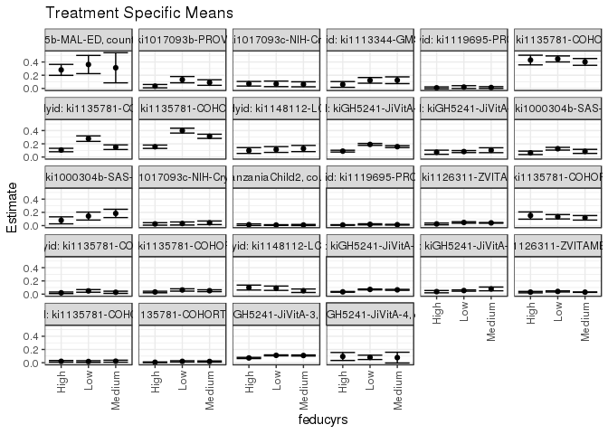

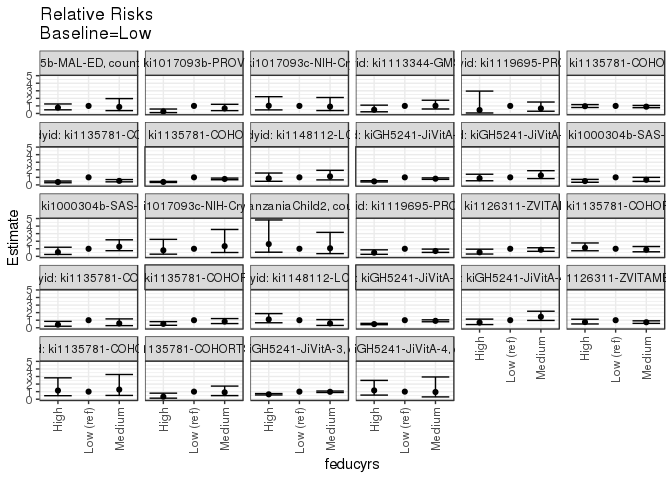

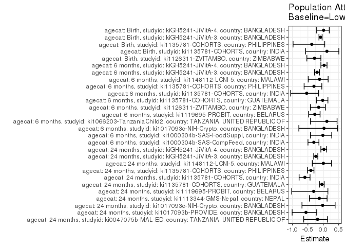

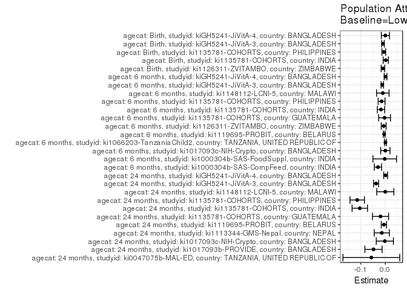

## Results Table

### Parameter: TSM

| agecat | studyid | country | intervention_level | baseline_level | estimate | ci_lower | ci_upper |
| --- | --- | --- | --- | --- | --- | --- | --- |
| Birth | ki1126311-ZVITAMBO | ZIMBABWE | Low | NA | 0.0408612 | 0.0327277 | 0.0489946 |
| Birth | ki1126311-ZVITAMBO | ZIMBABWE | Medium | NA | 0.0298785 | 0.0265757 | 0.0331814 |
| Birth | ki1126311-ZVITAMBO | ZIMBABWE | High | NA | 0.0307377 | 0.0199085 | 0.0415669 |
| Birth | ki1135781-COHORTS | INDIA | Low | NA | 0.0182232 | 0.0057064 | 0.0307401 |
| Birth | ki1135781-COHORTS | INDIA | Medium | NA | 0.0231959 | 0.0082128 | 0.0381790 |
| Birth | ki1135781-COHORTS | INDIA | High | NA | 0.0208729 | 0.0086629 | 0.0330828 |
| Birth | ki1135781-COHORTS | PHILIPPINES | Low | NA | 0.0205562 | 0.0108839 | 0.0302286 |
| Birth | ki1135781-COHORTS | PHILIPPINES | Medium | NA | 0.0186457 | 0.0103388 | 0.0269526 |
| Birth | ki1135781-COHORTS | PHILIPPINES | High | NA | 0.0068160 | 0.0017831 | 0.0118489 |
| Birth | kiGH5241-JiVitA-3 | BANGLADESH | Low | NA | 0.1113604 | 0.1041675 | 0.1185533 |
| Birth | kiGH5241-JiVitA-3 | BANGLADESH | Medium | NA | 0.1089910 | 0.1007805 | 0.1172015 |
| Birth | kiGH5241-JiVitA-3 | BANGLADESH | High | NA | 0.0718002 | 0.0626002 | 0.0810002 |
| Birth | kiGH5241-JiVitA-4 | BANGLADESH | Low | NA | 0.0810811 | 0.0483586 | 0.1138036 |
| Birth | kiGH5241-JiVitA-4 | BANGLADESH | Medium | NA | 0.0769231 | -0.0043285 | 0.1581746 |
| Birth | kiGH5241-JiVitA-4 | BANGLADESH | High | NA | 0.0943396 | 0.0339904 | 0.1546888 |
| 6 months | ki1000304b-SAS-CompFeed | INDIA | Low | NA | 0.1254545 | 0.1048049 | 0.1461041 |
| 6 months | ki1000304b-SAS-CompFeed | INDIA | Medium | NA | 0.0850575 | 0.0544578 | 0.1156572 |
| 6 months | ki1000304b-SAS-CompFeed | INDIA | High | NA | 0.0632184 | 0.0371438 | 0.0892930 |
| 6 months | ki1000304b-SAS-FoodSuppl | INDIA | Low | NA | 0.1439394 | 0.0839775 | 0.2039013 |
| 6 months | ki1000304b-SAS-FoodSuppl | INDIA | Medium | NA | 0.1836735 | 0.1209952 | 0.2463517 |
| 6 months | ki1000304b-SAS-FoodSuppl | INDIA | High | NA | 0.0792079 | 0.0264698 | 0.1319460 |
| 6 months | ki1017093c-NIH-Crypto | BANGLADESH | Low | NA | 0.0313901 | 0.0084883 | 0.0542920 |
| 6 months | ki1017093c-NIH-Crypto | BANGLADESH | Medium | NA | 0.0422535 | 0.0152190 | 0.0692881 |
| 6 months | ki1017093c-NIH-Crypto | BANGLADESH | High | NA | 0.0250896 | 0.0067251 | 0.0434541 |
| 6 months | ki1066203-TanzaniaChild2 | TANZANIA, UNITED REPUBLIC OF | Low | NA | 0.0083102 | 0.0029023 | 0.0137182 |
| 6 months | ki1066203-TanzaniaChild2 | TANZANIA, UNITED REPUBLIC OF | Medium | NA | 0.0088652 | 0.0011273 | 0.0166032 |
| 6 months | ki1066203-TanzaniaChild2 | TANZANIA, UNITED REPUBLIC OF | High | NA | 0.0134771 | 0.0017411 | 0.0252131 |
| 6 months | ki1119695-PROBIT | BELARUS | Low | NA | 0.0189534 | 0.0108867 | 0.0270200 |
| 6 months | ki1119695-PROBIT | BELARUS | Medium | NA | 0.0133610 | 0.0082664 | 0.0184557 |
| 6 months | ki1119695-PROBIT | BELARUS | High | NA | 0.0091524 | 0.0049725 | 0.0133323 |

[output cut: 54 more lines]

### Parameter: E(Y)

| agecat | studyid | country | intervention_level | baseline_level | estimate | ci_lower | ci_upper |
| --- | --- | --- | --- | --- | --- | --- | --- |
| Birth | ki1126311-ZVITAMBO | ZIMBABWE | NA | NA | 0.0317979 | 0.0288336 | 0.0347622 |
| Birth | ki1135781-COHORTS | INDIA | NA | NA | 0.0206795 | 0.0130966 | 0.0282623 |
| Birth | ki1135781-COHORTS | PHILIPPINES | NA | NA | 0.0149669 | 0.0105263 | 0.0194076 |
| Birth | kiGH5241-JiVitA-3 | BANGLADESH | NA | NA | 0.1024757 | 0.0976627 | 0.1072888 |
| Birth | kiGH5241-JiVitA-4 | BANGLADESH | NA | NA | 0.0820399 | 0.0540196 | 0.1100602 |
| 6 months | ki1000304b-SAS-CompFeed | INDIA | NA | NA | 0.0960240 | 0.0777684 | 0.1142796 |
| 6 months | ki1000304b-SAS-FoodSuppl | INDIA | NA | NA | 0.1421053 | 0.1069532 | 0.1772573 |
| 6 months | ki1017093c-NIH-Crypto | BANGLADESH | NA | NA | 0.0321678 | 0.0192256 | 0.0451101 |
| 6 months | ki1066203-TanzaniaChild2 | TANZANIA, UNITED REPUBLIC OF | NA | NA | 0.0094153 | 0.0052007 | 0.0136299 |
| 6 months | ki1119695-PROBIT | BELARUS | NA | NA | 0.0148577 | 0.0096205 | 0.0200949 |
| 6 months | ki1126311-ZVITAMBO | ZIMBABWE | NA | NA | 0.0409277 | 0.0366029 | 0.0452524 |
| 6 months | ki1135781-COHORTS | GUATEMALA | NA | NA | 0.1305310 | 0.1085580 | 0.1525039 |
| 6 months | ki1135781-COHORTS | INDIA | NA | NA | 0.0317690 | 0.0225290 | 0.0410089 |
| 6 months | ki1135781-COHORTS | PHILIPPINES | NA | NA | 0.0483619 | 0.0400565 | 0.0566674 |
| 6 months | ki1148112-LCNI-5 | MALAWI | NA | NA | 0.0800493 | 0.0613726 | 0.0987259 |
| 6 months | kiGH5241-JiVitA-3 | BANGLADESH | NA | NA | 0.0593851 | 0.0553716 | 0.0633986 |
| 6 months | kiGH5241-JiVitA-4 | BANGLADESH | NA | NA | 0.0557174 | 0.0473621 | 0.0640727 |
| 24 months | ki0047075b-MAL-ED | TANZANIA, UNITED REPUBLIC OF | NA | NA | 0.3050847 | 0.2370598 | 0.3731096 |
| 24 months | ki1017093b-PROVIDE | BANGLADESH | NA | NA | 0.0849220 | 0.0621566 | 0.1076874 |
| 24 months | ki1017093c-NIH-Crypto | BANGLADESH | NA | NA | 0.0680934 | 0.0462948 | 0.0898920 |
| 24 months | ki1113344-GMS-Nepal | NEPAL | NA | NA | 0.1084337 | 0.0810981 | 0.1357694 |
| 24 months | ki1119695-PROBIT | BELARUS | NA | NA | 0.0161002 | 0.0033894 | 0.0288110 |
| 24 months | ki1135781-COHORTS | GUATEMALA | NA | NA | 0.4271357 | 0.3963844 | 0.4578870 |
| 24 months | ki1135781-COHORTS | INDIA | NA | NA | 0.1739130 | 0.1539078 | 0.1939183 |
| 24 months | ki1135781-COHORTS | PHILIPPINES | NA | NA | 0.2843561 | 0.2659721 | 0.3027401 |
| 24 months | ki1148112-LCNI-5 | MALAWI | NA | NA | 0.1138354 | 0.0877614 | 0.1399093 |
| 24 months | kiGH5241-JiVitA-3 | BANGLADESH | NA | NA | 0.1535030 | 0.1445839 | 0.1624220 |
| 24 months | kiGH5241-JiVitA-4 | BANGLADESH | NA | NA | 0.0838901 | 0.0710207 | 0.0967596 |

### Parameter: RR

| agecat | studyid | country | intervention_level | baseline_level | estimate | ci_lower | ci_upper |
| --- | --- | --- | --- | --- | --- | --- | --- |
| Birth | ki1126311-ZVITAMBO | ZIMBABWE | Low | Low | 1.0000000 | 1.0000000 | 1.0000000 |
| Birth | ki1126311-ZVITAMBO | ZIMBABWE | Medium | Low | 0.7312207 | 0.5823257 | 0.9181868 |
| Birth | ki1126311-ZVITAMBO | ZIMBABWE | High | Low | 0.7522475 | 0.5019064 | 1.1274539 |
| Birth | ki1135781-COHORTS | INDIA | Low | Low | 1.0000000 | 1.0000000 | 1.0000000 |
| Birth | ki1135781-COHORTS | INDIA | Medium | Low | 1.2728737 | 0.4957916 | 3.2679204 |
| Birth | ki1135781-COHORTS | INDIA | High | Low | 1.1453985 | 0.4646603 | 2.8234341 |
| Birth | ki1135781-COHORTS | PHILIPPINES | Low | Low | 1.0000000 | 1.0000000 | 1.0000000 |
| Birth | ki1135781-COHORTS | PHILIPPINES | Medium | Low | 0.9070600 | 0.4744831 | 1.7340087 |
| Birth | ki1135781-COHORTS | PHILIPPINES | High | Low | 0.3315768 | 0.1381425 | 0.7958680 |
| Birth | kiGH5241-JiVitA-3 | BANGLADESH | Low | Low | 1.0000000 | 1.0000000 | 1.0000000 |
| Birth | kiGH5241-JiVitA-3 | BANGLADESH | Medium | Low | 0.9787229 | 0.8876400 | 1.0791522 |
| Birth | kiGH5241-JiVitA-3 | BANGLADESH | High | Low | 0.6447552 | 0.5580007 | 0.7449977 |
| Birth | kiGH5241-JiVitA-4 | BANGLADESH | Low | Low | 1.0000000 | 1.0000000 | 1.0000000 |
| Birth | kiGH5241-JiVitA-4 | BANGLADESH | Medium | Low | 0.9487179 | 0.3062489 | 2.9390008 |
| Birth | kiGH5241-JiVitA-4 | BANGLADESH | High | Low | 1.1635220 | 0.5448621 | 2.4846352 |
| 6 months | ki1000304b-SAS-CompFeed | INDIA | Low | Low | 1.0000000 | 1.0000000 | 1.0000000 |
| 6 months | ki1000304b-SAS-CompFeed | INDIA | Medium | Low | 0.6779943 | 0.4621932 | 0.9945545 |
| 6 months | ki1000304b-SAS-CompFeed | INDIA | High | Low | 0.5039147 | 0.3486174 | 0.7283917 |
| 6 months | ki1000304b-SAS-FoodSuppl | INDIA | Low | Low | 1.0000000 | 1.0000000 | 1.0000000 |
| 6 months | ki1000304b-SAS-FoodSuppl | INDIA | Medium | Low | 1.2760473 | 0.7447272 | 2.1864336 |
| 6 months | ki1000304b-SAS-FoodSuppl | INDIA | High | Low | 0.5502866 | 0.2508965 | 1.2069336 |
| 6 months | ki1017093c-NIH-Crypto | BANGLADESH | Low | Low | 1.0000000 | 1.0000000 | 1.0000000 |
| 6 months | ki1017093c-NIH-Crypto | BANGLADESH | Medium | Low | 1.3460765 | 0.5100738 | 3.5522739 |
| 6 months | ki1017093c-NIH-Crypto | BANGLADESH | High | Low | 0.7992832 | 0.2843614 | 2.2466251 |
| 6 months | ki1066203-TanzaniaChild2 | TANZANIA, UNITED REPUBLIC OF | Low | Low | 1.0000000 | 1.0000000 | 1.0000000 |
| 6 months | ki1066203-TanzaniaChild2 | TANZANIA, UNITED REPUBLIC OF | Medium | Low | 1.0667849 | 0.3591237 | 3.1689079 |
| 6 months | ki1066203-TanzaniaChild2 | TANZANIA, UNITED REPUBLIC OF | High | Low | 1.6217430 | 0.5468357 | 4.8095809 |
| 6 months | ki1119695-PROBIT | BELARUS | Low | Low | 1.0000000 | 1.0000000 | 1.0000000 |
| 6 months | ki1119695-PROBIT | BELARUS | Medium | Low | 0.7049429 | 0.5195169 | 0.9565513 |
| 6 months | ki1119695-PROBIT | BELARUS | High | Low | 0.4828907 | 0.2711969 | 0.8598308 |

[output cut: 54 more lines]

### Parameter: PAR

| agecat | studyid | country | intervention_level | baseline_level | estimate | ci_lower | ci_upper |
| --- | --- | --- | --- | --- | --- | --- | --- |
| Birth | ki1126311-ZVITAMBO | ZIMBABWE | Low | NA | -0.0090632 | -0.0163136 | -0.0018129 |
| Birth | ki1135781-COHORTS | INDIA | Low | NA | 0.0024562 | -0.0081540 | 0.0130665 |
| Birth | ki1135781-COHORTS | PHILIPPINES | Low | NA | -0.0055893 | -0.0132974 | 0.0021188 |
| Birth | kiGH5241-JiVitA-3 | BANGLADESH | Low | NA | -0.0088847 | -0.0141295 | -0.0036398 |
| Birth | kiGH5241-JiVitA-4 | BANGLADESH | Low | NA | 0.0009588 | -0.0157106 | 0.0176283 |
| 6 months | ki1000304b-SAS-CompFeed | INDIA | Low | NA | -0.0294305 | -0.0443036 | -0.0145574 |
| 6 months | ki1000304b-SAS-FoodSuppl | INDIA | Low | NA | -0.0018341 | -0.0501375 | 0.0464693 |
| 6 months | ki1017093c-NIH-Crypto | BANGLADESH | Low | NA | 0.0007777 | -0.0183228 | 0.0198782 |
| 6 months | ki1066203-TanzaniaChild2 | TANZANIA, UNITED REPUBLIC OF | Low | NA | 0.0011050 | -0.0028469 | 0.0050570 |
| 6 months | ki1119695-PROBIT | BELARUS | Low | NA | -0.0040957 | -0.0076260 | -0.0005654 |
| 6 months | ki1126311-ZVITAMBO | ZIMBABWE | Low | NA | -0.0060809 | -0.0160106 | 0.0038489 |
| 6 months | ki1135781-COHORTS | GUATEMALA | Low | NA | -0.0024740 | -0.0268455 | 0.0218976 |
| 6 months | ki1135781-COHORTS | INDIA | Low | NA | -0.0171199 | -0.0321025 | -0.0021373 |
| 6 months | ki1135781-COHORTS | PHILIPPINES | Low | NA | -0.0146407 | -0.0286452 | -0.0006363 |
| 6 months | ki1148112-LCNI-5 | MALAWI | Low | NA | -0.0096059 | -0.0352592 | 0.0160474 |
| 6 months | kiGH5241-JiVitA-3 | BANGLADESH | Low | NA | -0.0118395 | -0.0167458 | -0.0069333 |
| 6 months | kiGH5241-JiVitA-4 | BANGLADESH | Low | NA | 0.0015549 | -0.0039895 | 0.0070993 |
| 24 months | ki0047075b-MAL-ED | TANZANIA, UNITED REPUBLIC OF | Low | NA | -0.0566174 | -0.1729201 | 0.0596854 |
| 24 months | ki1017093b-PROVIDE | BANGLADESH | Low | NA | -0.0477311 | -0.0829806 | -0.0124815 |
| 24 months | ki1017093c-NIH-Crypto | BANGLADESH | Low | NA | -0.0013511 | -0.0364885 | 0.0337863 |
| 24 months | ki1113344-GMS-Nepal | NEPAL | Low | NA | -0.0137382 | -0.0446782 | 0.0172018 |
| 24 months | ki1119695-PROBIT | BELARUS | Low | NA | -0.0050080 | -0.0158396 | 0.0058236 |
| 24 months | ki1135781-COHORTS | GUATEMALA | Low | NA | -0.0189850 | -0.0519021 | 0.0139321 |
| 24 months | ki1135781-COHORTS | INDIA | Low | NA | -0.1038647 | -0.1354294 | -0.0723001 |
| 24 months | ki1135781-COHORTS | PHILIPPINES | Low | NA | -0.1144878 | -0.1440367 | -0.0849390 |
| 24 months | ki1148112-LCNI-5 | MALAWI | Low | NA | 0.0005349 | -0.0345389 | 0.0356087 |
| 24 months | kiGH5241-JiVitA-3 | BANGLADESH | Low | NA | -0.0370860 | -0.0473589 | -0.0268130 |
| 24 months | kiGH5241-JiVitA-4 | BANGLADESH | Low | NA | 0.0018728 | -0.0060514 | 0.0097970 |

### Parameter: PAF

| agecat | studyid | country | intervention_level | baseline_level | estimate | ci_lower | ci_upper |
| --- | --- | --- | --- | --- | --- | --- | --- |
| Birth | ki1126311-ZVITAMBO | ZIMBABWE | Low | NA | -0.2850262 | -0.5328241 | -0.0772876 |
| Birth | ki1135781-COHORTS | INDIA | Low | NA | 0.1187764 | -0.5742366 | 0.5067101 |
| Birth | ki1135781-COHORTS | PHILIPPINES | Low | NA | -0.3734428 | -0.9815609 | 0.0480509 |
| Birth | kiGH5241-JiVitA-3 | BANGLADESH | Low | NA | -0.0867002 | -0.1391857 | -0.0366329 |
| Birth | kiGH5241-JiVitA-4 | BANGLADESH | Low | NA | 0.0116874 | -0.2139834 | 0.1954076 |
| 6 months | ki1000304b-SAS-CompFeed | INDIA | Low | NA | -0.3064915 | -0.4970549 | -0.1401853 |
| 6 months | ki1000304b-SAS-FoodSuppl | INDIA | Low | NA | -0.0129068 | -0.4167931 | 0.2758433 |
| 6 months | ki1017093c-NIH-Crypto | BANGLADESH | Low | NA | 0.0241763 | -0.7930856 | 0.4689423 |
| 6 months | ki1066203-TanzaniaChild2 | TANZANIA, UNITED REPUBLIC OF | Low | NA | 0.1173640 | -0.4148639 | 0.4493843 |
| 6 months | ki1119695-PROBIT | BELARUS | Low | NA | -0.2756625 | -0.4754710 | -0.1029122 |
| 6 months | ki1126311-ZVITAMBO | ZIMBABWE | Low | NA | -0.1485755 | -0.4181533 | 0.0697580 |
| 6 months | ki1135781-COHORTS | GUATEMALA | Low | NA | -0.0189530 | -0.2238417 | 0.1516344 |
| 6 months | ki1135781-COHORTS | INDIA | Low | NA | -0.5388889 | -1.0583609 | -0.1505169 |
| 6 months | ki1135781-COHORTS | PHILIPPINES | Low | NA | -0.3027329 | -0.6219319 | -0.0463528 |
| 6 months | ki1148112-LCNI-5 | MALAWI | Low | NA | -0.1200000 | -0.4897099 | 0.1579569 |
| 6 months | kiGH5241-JiVitA-3 | BANGLADESH | Low | NA | -0.1993691 | -0.2838862 | -0.1204156 |
| 6 months | kiGH5241-JiVitA-4 | BANGLADESH | Low | NA | 0.0279073 | -0.0766675 | 0.1223249 |
| 24 months | ki0047075b-MAL-ED | TANZANIA, UNITED REPUBLIC OF | Low | NA | -0.1855792 | -0.6353420 | 0.1404868 |
| 24 months | ki1017093b-PROVIDE | BANGLADESH | Low | NA | -0.5620575 | -1.0117300 | -0.2128982 |
| 24 months | ki1017093c-NIH-Crypto | BANGLADESH | Low | NA | -0.0198413 | -0.6914616 | 0.3851021 |
| 24 months | ki1113344-GMS-Nepal | NEPAL | Low | NA | -0.1266968 | -0.4497416 | 0.1243641 |
| 24 months | ki1119695-PROBIT | BELARUS | Low | NA | -0.3110525 | -1.0248763 | 0.1511291 |
| 24 months | ki1135781-COHORTS | GUATEMALA | Low | NA | -0.0444473 | -0.1244662 | 0.0298774 |
| 24 months | ki1135781-COHORTS | INDIA | Low | NA | -0.5972222 | -0.7846117 | -0.4295092 |
| 24 months | ki1135781-COHORTS | PHILIPPINES | Low | NA | -0.4026214 | -0.5108844 | -0.3021159 |
| 24 months | ki1148112-LCNI-5 | MALAWI | Low | NA | 0.0046988 | -0.3564260 | 0.2696804 |
| 24 months | kiGH5241-JiVitA-3 | BANGLADESH | Low | NA | -0.2415978 | -0.3101474 | -0.1766348 |
| 24 months | kiGH5241-JiVitA-4 | BANGLADESH | Low | NA | 0.0223245 | -0.0770084 | 0.1124959 |